# Project

Sarah Fitzgerald

```
    Quality          Amount        Variety
 Min.   :3.000   Min.   :2.00   Min.   :2.000
 1st Qu.:4.000   1st Qu.:4.00   1st Qu.:4.000
 Median :5.000   Median :4.00   Median :4.000
 Mean   :4.708   Mean   :4.25   Mean   :4.328
 3rd Qu.:5.000   3rd Qu.:5.00   3rd Qu.:5.000
 Max.   :5.000   Max.   :5.00   Max.   :5.000
 NA's   :11      NA's   :12     NA's   :12
```

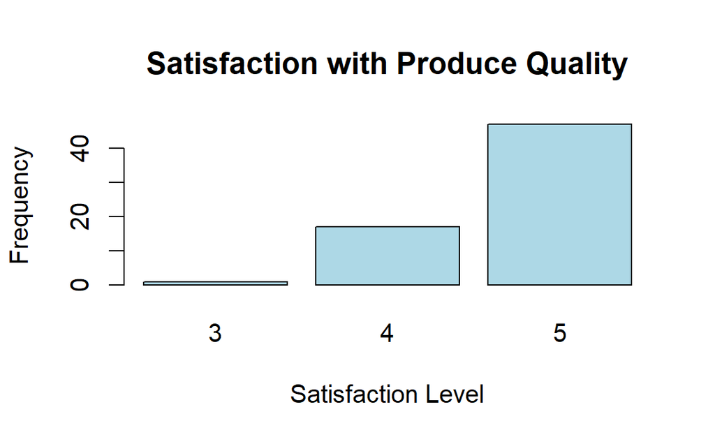

The majority of respondents rated their satisfaction with produce quality at the highest level, 5 (“Very Satisfied”), followed by a smaller but notable group who rated it as 4 (“Satisfied”). Very few respondents selected level 3 (“Neither dissatisfied nor satisfied”), and no respondents provided ratings of 1 (“Very Dissatisfied”) or 2 (“Dissatisfied”). This absence of dissatisfaction highlights a high level of customer satisfaction and indicates that the market is successfully meeting or exceeding customer expectations regarding produce quality.

These findings emphasize that produce quality is a key strength of the market. While the results are overwhelmingly positive, monitoring “Satisfied” (4) responses may provide opportunities for improvement to further elevate satisfaction levels to “Very Satisfied” (5). This proactive approach could help solidify customer loyalty and enhance the market’s reputation.

| Rank | Quality | Amount | Variety |
| --- | --- | --- | --- |
| 1 | 24 | 7 | 18 |
| 2 | 8 | 20 | 24 |
| 3 | 17 | 21 | 15 |

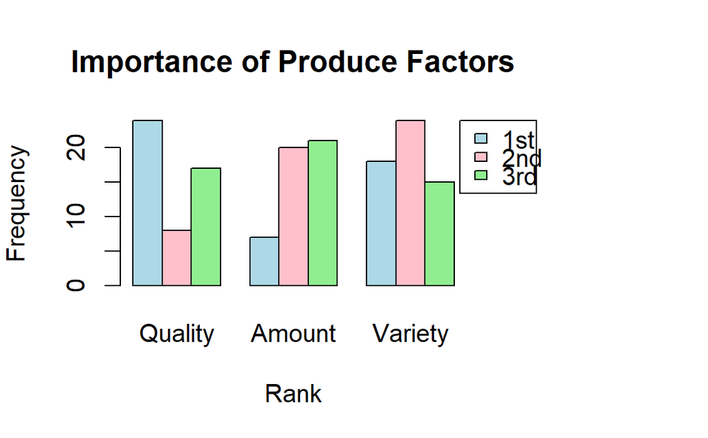

In contrast, amount was ranked as less important overall, with higher frequencies observed for Ranks 2 and 3 compared to Rank 1. While availability of produce remains a consideration, it does not carry as much weight as quality. Variety displayed a more balanced distribution across ranks, often appearing as the second or third most important factor. This suggests mixed opinions about the importance of variety, with some customers valuing diversity in their produce options while others prioritize other factors.

Given these findings, the market should continue to prioritize the maintenance and improvement of produce quality. Expanding the diversity of produce offerings could appeal to customers who place greater value on variety, while ensuring adequate stock levels may help address secondary concerns related to availability.

```
[1] "Summary Statistics:"
     Q12_1            Q12_2
 Min.   :0.0000   Min.   :0.0000
 1st Qu.:1.0000   1st Qu.:1.0000
 Median :1.0000   Median :1.0000
 Mean   :0.8947   Mean   :0.8026
 3rd Qu.:1.0000   3rd Qu.:1.0000
 Max.   :1.0000   Max.   :1.0000
     Q12_3            Q12_4
 Min.   :0.0000   Min.   :0.0000
 1st Qu.:0.0000   1st Qu.:0.0000
 Median :1.0000   Median :1.0000
 Mean   :0.6184   Mean   :0.6447
 3rd Qu.:1.0000   3rd Qu.:1.0000
 Max.   :1.0000   Max.   :1.0000
[1] "Mean, Median, and Standard Deviation for each produce type:"
```

|  | Produce | Mean | Median | Standard_Deviation |
| --- | --- | --- | --- | --- |
| Q12_1 | Vegetables | 0.8947368 | 1 | 0.3089314 |
| Q12_2 | Fruits | 0.8026316 | 1 | 0.4006574 |
| Q12_3 | Flowers | 0.6184211 | 1 | 0.4890018 |
| Q12_4 | Herbs | 0.6447368 | 1 | 0.4817730 |

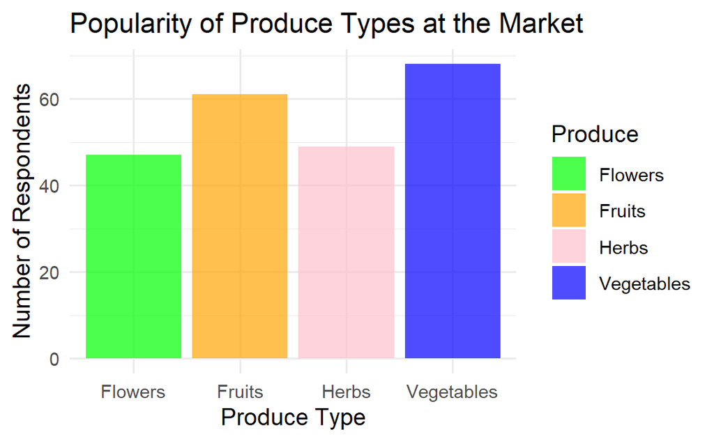

```
[1] "Contingency Table:"

     0  1
  0  5  3
  1 10 58
```

```
[1] "Chi-Square Test Results:"

    Pearson's Chi-squared test with Yates'
    continuity correction

data:  contingency_table
X-squared = 7.5249, df = 1, p-value =
0.006085
```

The analysis of product preferences further supports the importance of produce quality. Vegetables were the most frequently chosen product category, with a mean of 0.89 (approximately 89% of respondents), a standard deviation of 0.31, and a median of 1. Similarly, fruits were selected by 80% of respondents (mean = 0.80), with a slightly higher standard deviation of 0.40.

Other produce items, such as herbs and flowers, showed moderate selection frequencies. Herbs were chosen by approximately 64% of respondents (mean = 0.64, standard deviation = 0.48), while flowers had a mean of 0.62 (62% of respondents) and a standard deviation of 0.49. Notably, no respondents selected “None,” indicating that all surveyed customers expressed interest in at least one produce category.

These preferences highlight a strong demand for vegetables and fruits, followed by moderate interest in herbs and flowers. This information can help the market align its offerings with customer demand to maintain satisfaction and meet expectations.

A chi-square test was conducted to examine the association between the choice of vegetables and the choice of fruits. The results yielded a test statistic of 7.5249, with 1 degree of freedom and a p-value of 0.0061. Since the p-value is less than the significance level of 0.05, we reject the null hypothesis that the two variables are independent.

These findings indicate a statistically significant association between the choice of vegetables and fruits. In other words, respondents who selected vegetables were more likely to also select fruits, and vice versa. This highlights complementary purchasing behavior among customers and suggests that both categories play a central role in their shopping preferences.

```
[1] "Top words:"
```

|  | filtered_words | Freq |
| --- | --- | --- |
| 1 | fruit | 7 |
| 2 | carrots | 5 |
| 3 | cucumbers | 5 |
| 4 | potatoes | 5 |
| 5 | eggs | 4 |
| 6 | strawberries | 4 |
| 7 | corn | 3 |
| 8 | zucchini | 3 |
| 9 | beans | 2 |
| 10 | brussels | 2 |

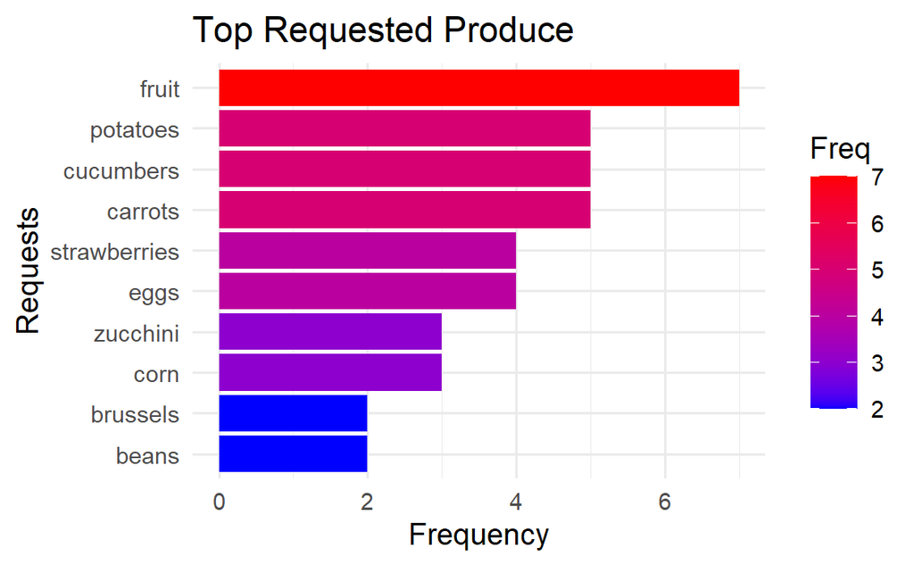

The bar chart titled “Top Requested Produce” illustrates the specific produce items customers most frequently requested to see at the market, using a color gradient to reflect frequency levels. Higher frequencies are represented in red, while lower frequencies appear in blue, providing a clear visual indication of demand intensity across various produce categories.

Top Requested Item: Fruit stands out as the most requested produce item, with a frequency of 7. This strong demand likely reflects both general fruit preferences and specific items such as apples, oranges, or berries. The high frequency suggests that customers view fruit as an essential offering and expect a diverse and consistent selection.

Second Tier of Requests: The next most requested items—potatoes, cucumbers, and carrots—each have a frequency of 5. These vegetables are common household staples, indicating that customers prioritize availability of reliable, versatile produce for daily use. Their high placement underscores their importance in meeting core shopping needs.

Mid-Tier Requests: Items like strawberries and eggs, each with a frequency of 4, occupy the middle tier of requests. The interest in strawberries may reflect seasonal demand or preferences for fresh, high-quality fruit options. Meanwhile, the request for eggs highlights customer interest in expanding the market’s offerings beyond fruits and vegetables, signaling a demand for broader produce-related goods.

Lower-Tier Requests: The chart also captures requests for zucchini and corn (each with a frequency of 3) as well as brussel sprouts and beans (each with a frequency of 2). While these items were mentioned less frequently, they still represent targeted preferences and niche demands. Their inclusion suggests that some customers seek specific produce to meet dietary needs or personal preferences, highlighting opportunities to cater to smaller but valuable market segments.

In summary, the data reveals a clear hierarchy of customer requests, with fruits dominating the list, followed by staple vegetables and select niche items. These insights can guide the market in prioritizing produce offerings to better align with customer preferences and expectations.

```
 1  2  3  4  5
41 10  5  4  3
```

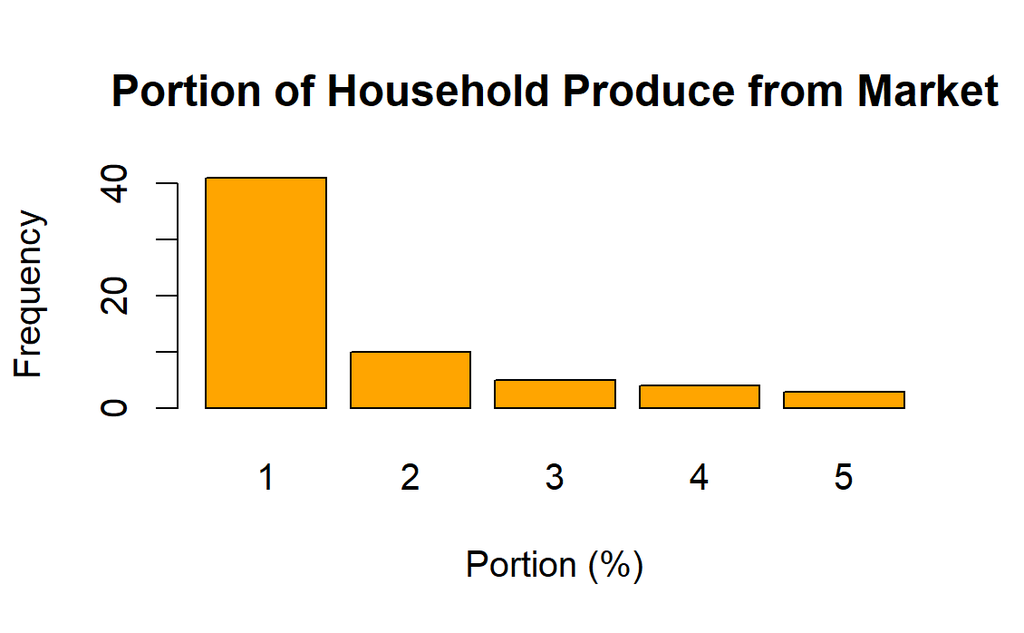

When asked about the portion of household produce obtained from the market, most respondents (over 40 individuals) indicated that they purchase less than 25% of their produce at the market. A smaller group reported obtaining between 25% and 50% of their produce, while very few respondents indicated purchasing more than 50%. The smallest frequencies were observed for the highest portion (more than 75%).

This sharp decline in frequencies as the percentage increases suggests that the market is not the primary source of household produce for most customers. While the market successfully meets certain needs, these results may indicate opportunities to attract customers who currently rely on alternative sources for larger portions of their produce.

```
     1  2  3  4  5
  3  0  0  0  0  0
  4 11  5  0  1  0
  5 30  5  5  3  3
[1] 11
[1] 13

    Fisher's Exact Test for Count Data

data:  contingency_table
p-value = 0.2746
alternative hypothesis: two.sided
```

A Fisher’s Exact Test for Count Data was performed to investigate whether there is a relationship between customer satisfaction levels and the portion of produce obtained from the market. The test yielded a p-value of 0.2746, which is greater than the commonly used significance level of 0.05.

Given that the p-value exceeds this threshold, we fail to reject the null hypothesis, which suggests that there is no significant association between satisfaction levels and the amount of produce customers obtain. In other words, the data does not provide sufficient evidence to conclude that satisfaction with produce quality influences the proportion of produce purchased by customers.

This result indicates that while customers may have varying satisfaction levels, their purchasing behavior, in terms of the amount of produce they acquire, does not appear to be strongly influenced by how satisfied they are with the produce. It is important to note, however, that other factors, such as availability, or personal preferences, may play a more prominent role in determining how much produce customers choose to purchase.

Overall, customer satisfaction with produce quality is exceptionally high, with very few signs of dissatisfaction. Quality remains the most important factor for customers, followed by varying degrees of importance for variety and amount. Vegetables and fruits are the most frequently chosen products, and there is a notable association between their selection.

The market is primarily relied upon for small portions of household produce, which presents an opportunity to increase its role as a primary source. Customer requests highlight strong demand for fruits and staple vegetables, with mid-tier and niche preferences also contributing to overall interest.

Key Recommendations: Maintain and enhance produce quality to sustain high satisfaction levels and meet customer expectations.

Expand fruit and vegetable offerings to align with customer demand, particularly for top-requested items.

Increase variety and specialty options to appeal to customers with niche preferences.

Promote the market’s role as a primary produce source by addressing concerns related to availability and quantity.